# Day 2 – 01 Explore Data

Seminar plotting walk-through

We start the Day 2 session with the already prepared file `second_day_part2/data/dataset1_subset_long.csv`. This document simply shows how to open that file with base R commands and how to inspect what is inside before we move on to plotting. Run `second_day_part2/data/00_prepare_dataset.Rmd` first if you need to regenerate the CSV. Knit it from the repository root with:

```
R -e "rmarkdown::render('second_day_part2/scripts/01_explore_data.Rmd')"
```

## 1. Load the CSV

```r
input_path <- file.path('..', 'data', 'dataset1_subset_long.csv')
long_df <- read.csv(input_path, stringsAsFactors = FALSE, check.names = FALSE)

cat('Rows:', nrow(long_df), '\\nColumns:', ncol(long_df), '\\n')
```

```
## Rows: 1536 \nColumns: 7 \n
```

## 2. Look at column names and a small preview

`colnames()` lists the headers exactly as they appear in the CSV and `head()` prints the first few rows. Encourage learners to read these outputs aloud so they begin to map column names to real-world meaning (genome name, SNP id, mouse ID, day, value, …).

```r
colnames(long_df)
```

```
## [1] "Genome"          "snp_id"          "Position"        "value"
## [5] "mouse_id"        "day"             "treatment_group"
```

```r
head(long_df)
```

```
##                         Genome      snp_id Position    value mouse_id day
## 1 Akkermansia_muciniphila_YL44  239840-C-G   239840 0.000000     1683   0
## 2 Akkermansia_muciniphila_YL44  241793-A-G   241793 0.049587     1683   0
## 3 Akkermansia_muciniphila_YL44  355328-A-T   355328 0.138182     1683   0
## 4 Akkermansia_muciniphila_YL44  356291-C-A   356291 0.000000     1683   0
## 5 Akkermansia_muciniphila_YL44 2351445-C-T  2351445 0.000000     1683   0
## 6   Bacteroides_caecimuris_I48 1601848-T-C  1601848 0.041609     1683   0
##   treatment_group
## 1         Control
## 2         Control
## 3         Control
## 4         Control
## 5         Control
## 6         Control
```

It can also help to peek at the SNP identifiers themselves to remind everyone what a typical label looks like:

```r
head(unique(long_df$snp_id), n = 5)
```

```
## [1] "239840-C-G"  "241793-A-G"  "355328-A-T"  "356291-C-A"  "2351445-C-T"
```

## 3. Which genomes are present?

We often start by asking “Which genomes are represented here?”. `unique()` returns all distinct values, while `table()` counts how many rows belong to each genome.

```r
unique(long_df$Genome)
```

```
## [1] "Akkermansia_muciniphila_YL44" "Bacteroides_caecimuris_I48"
```

```r
table(long_df$Genome)
```

```
##
## Akkermansia_muciniphila_YL44   Bacteroides_caecimuris_I48
##                          320                         1216
```

Explain to students that each row contains the `Genome`, the unique SNP id, the mouse ID, the day of sampling, and the measured value.

## 4. How many SNPs per genome?

Counting the unique SNP identifiers per genome shows how much information we keep for each organism. The helper `tapply(values, groups, FUN)` applies a function to each subset of `values` defined by `groups`. Here we give it the vector of SNP ids and ask it to count how many unique ids (`length(unique(x))`) exist inside each genome group.

```r
snp_per_genome <- tapply(long_df$snp_id, long_df$Genome, function(x) length(unique(x)))
snp_per_genome
```

```
## Akkermansia_muciniphila_YL44   Bacteroides_caecimuris_I48
##                            5                           19
```

## 6. How many measurements per mouse and per day?

```r
table(long_df$mouse_id)
```

```
##
## 1683 1688 1692 1699
##  384  384  384  384
```

```r
table(long_df$day)
```

```
##
##  0  4  9 14 18 23 30 37 44 49 53 58 63 67 72 79
## 96 96 96 96 96 96 96 96 96 96 96 96 96 96 96 96
```

For a combined view you can also build a two-way table. Again we use `table()`, this time with `mouse_id` on rows and `day` on columns. Reading across a row shows how many time points we have for a given mouse.

```r
table(long_df$mouse_id, long_df$day)
```

```
##
##         0  4  9 14 18 23 30 37 44 49 53 58 63 67 72 79
##   1683 24 24 24 24 24 24 24 24 24 24 24 24 24 24 24 24
##   1688 24 24 24 24 24 24 24 24 24 24 24 24 24 24 24 24
##   1692 24 24 24 24 24 24 24 24 24 24 24 24 24 24 24 24
##   1699 24 24 24 24 24 24 24 24 24 24 24 24 24 24 24 24
```

Pick any cell and inspect those rows directly. For example, mouse 1683 on day 0 has the following measurements (all SNPs for that mouse/day):

```r
subset_example <- long_df[long_df$mouse_id == '1683' & long_df$day == 0, ]
subset_example
```

```
##                          Genome      snp_id Position    value mouse_id day
## 1  Akkermansia_muciniphila_YL44  239840-C-G   239840 0.000000     1683   0
## 2  Akkermansia_muciniphila_YL44  241793-A-G   241793 0.049587     1683   0
## 3  Akkermansia_muciniphila_YL44  355328-A-T   355328 0.138182     1683   0
## 4  Akkermansia_muciniphila_YL44  356291-C-A   356291 0.000000     1683   0
## 5  Akkermansia_muciniphila_YL44 2351445-C-T  2351445 0.000000     1683   0
## 6    Bacteroides_caecimuris_I48 1601848-T-C  1601848 0.041609     1683   0
## 7    Bacteroides_caecimuris_I48 1602949-A-G  1602949 0.000000     1683   0
## 8    Bacteroides_caecimuris_I48 2105155-C-T  2105155 0.113208     1683   0
## 9    Bacteroides_caecimuris_I48 2562529-T-C  2562529 0.000000     1683   0
## 10   Bacteroides_caecimuris_I48 2958703-C-A  2958703 0.000000     1683   0
## 11   Bacteroides_caecimuris_I48 2963503-C-A  2963503 0.000000     1683   0
## 12   Bacteroides_caecimuris_I48 2964459-G-T  2964459 0.000000     1683   0
## 13   Bacteroides_caecimuris_I48 2973657-A-G  2973657 0.000000     1683   0
## 14   Bacteroides_caecimuris_I48 2975719-A-G  2975719 0.000000     1683   0
```

[output cut: 35 more lines]

## 6. What do the allele-frequency values look like?

Start by focusing on a single genome (Akkermansia) so the histogram is easy to interpret, then compare it against the combined dataset.

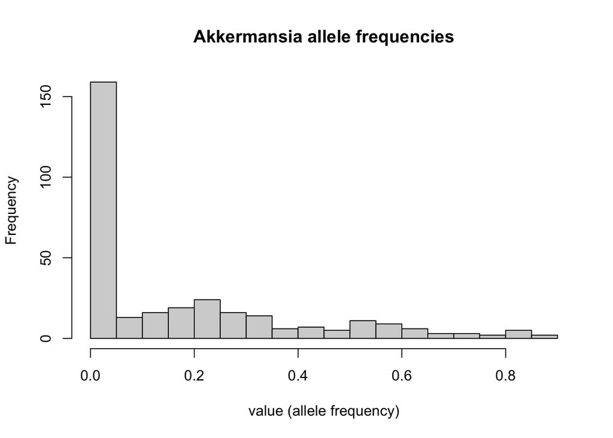

```r
akk_values <- long_df$value[long_df$Genome == 'Akkermansia_muciniphila_YL44']
hist(akk_values, breaks = 20, main = 'Akkermansia allele frequencies', xlab = 'value (allele frequency)')
```

```r
summary(akk_values)
```

```
##    Min. 1st Qu.  Median    Mean 3rd Qu.    Max.
## 0.00000 0.00000 0.05231 0.17419 0.27145 0.87125
```

Do the same for Bacteroides (the other genome in this dataset).

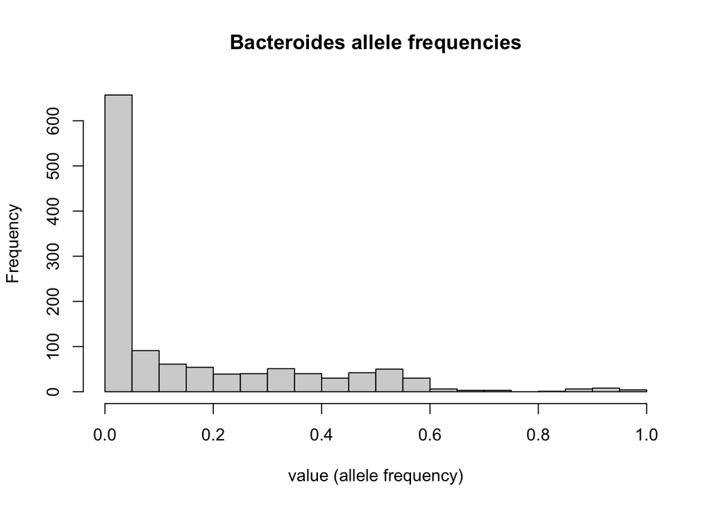

```r
bacto_values <- long_df$value[long_df$Genome == 'Bacteroides_caecimuris_I48']
hist(bacto_values, breaks = 20, main = 'Bacteroides allele frequencies', xlab = 'value (allele frequency)')
```

```r
summary(bacto_values)
```

```
##    Min. 1st Qu.  Median    Mean 3rd Qu.    Max.
## 0.00000 0.00000 0.03383 0.14854 0.26792 0.99122
```

Now look at the complete long table to see how the mixture of genomes changes the distribution.

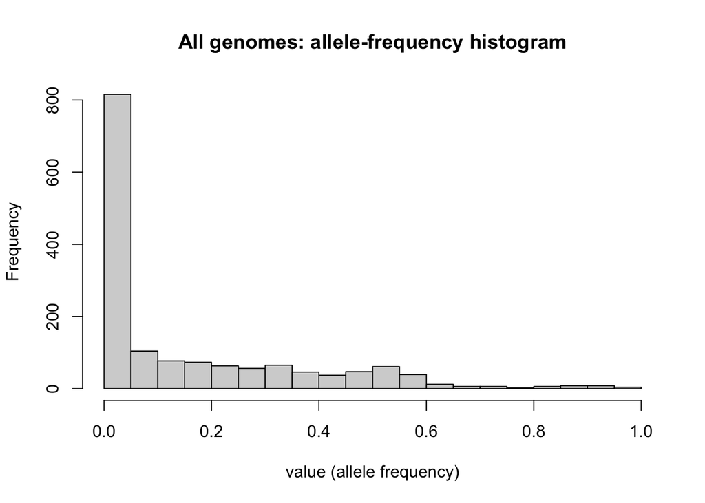

```r
hist(long_df$value, breaks = 30, main = 'All genomes: allele-frequency histogram', xlab = 'value (allele frequency)')
```

```r
summary(long_df$value)
```

```
##    Min. 1st Qu.  Median    Mean 3rd Qu.    Max.
## 0.00000 0.00000 0.03941 0.15388 0.27070 0.99122
```

To compare genomes explicitly, break the summary down by genome using `aggregate(value ~ Genome, ...)`. Read `value ~ Genome` as “value grouped by Genome”. The column on the left must be numeric because we are calling `summary()` on it.

```r
value_by_genome <- aggregate(value ~ Genome, data = long_df, function(x) summary(x))
value_by_genome
```

```
##                         Genome value.Min. value.1st Qu. value.Median value.Mean
## 1 Akkermansia_muciniphila_YL44  0.0000000     0.0000000    0.0523090  0.1741893
## 2   Bacteroides_caecimuris_I48  0.0000000     0.0000000    0.0338305  0.1485411
##   value.3rd Qu. value.Max.
## 1     0.2714463  0.8712450
## 2     0.2679232  0.9912180
```

## 7. How many missing values?

Count how many `NA` values appear in `value` and, if any, locate them by mouse/day.

```r
na_total <- sum(is.na(long_df$value))
na_total
```

```
## [1] 0
```

```r
na_by_mouse_day <- with(long_df, tapply(value, list(mouse_id, day), function(x) sum(is.na(x))))
na_by_mouse_day
```

```
##      0 4 9 14 18 23 30 37 44 49 53 58 63 67 72 79
## 1683 0 0 0  0  0  0  0  0  0  0  0  0  0  0  0  0
## 1688 0 0 0  0  0  0  0  0  0  0  0  0  0  0  0  0
## 1692 0 0 0  0  0  0  0  0  0  0  0  0  0  0  0  0
## 1699 0 0 0  0  0  0  0  0  0  0  0  0  0  0  0  0
```

## 8. Treatment-group overview

The long table now contains a `treatment_group` column. Start by listing the distinct labels and counting how many rows belong to each group.

```r
unique(long_df$treatment_group)
```

```
## [1] "Control"       "Ciprofloxacin" "Tetracyclin"   "Vancomycin"
```

```r
table(long_df$treatment_group)
```

```
##
## Ciprofloxacin       Control   Tetracyclin    Vancomycin
##           384           384           384           384
```

Which treatment groups appear for each mouse? Use a cross-tabulation to reinforce how mice were assigned.

```r
table(long_df$mouse_id, long_df$treatment_group)
```

```
##
##        Ciprofloxacin Control Tetracyclin Vancomycin
##   1683             0     384           0          0
##   1688           384       0           0          0
##   1692             0       0         384          0
##   1699             0       0           0        384
```

You can also inspect specific days. For example, day 30 only:

```r
subset_day30 <- long_df[long_df$day == 30, c('mouse_id', 'treatment_group')]
unique(subset_day30)
```

```
##      mouse_id treatment_group
## 97       1683         Control
## 481      1688   Ciprofloxacin
## 865      1692     Tetracyclin
## 1249     1699      Vancomycin
```

## 9. Focus on a single genome (Akkermansia)

Subsetting is a great way to answer specific questions. Below we keep only `Akkermansia_muciniphila_YL44` (using a logical comparison inside the square brackets) and inspect the resulting table. This demonstrates how to focus on one organism without altering the original data frame.

Explain that `long_df$Genome == 'Akkermansia_muciniphila_YL44'` evaluates to a vector of TRUE/FALSE values—TRUE where the genome matches that text and FALSE everywhere else. When we place that logical vector inside `[...]`, R keeps only the TRUE rows.

```r
akk_df <- long_df[long_df$Genome == 'Akkermansia_muciniphila_YL44', ]
cat('Rows for Akkermansia:', nrow(akk_df), '\n')
```

```
## Rows for Akkermansia: 320
```

```r
head(akk_df)
```

```
##                          Genome      snp_id Position    value mouse_id day
## 1  Akkermansia_muciniphila_YL44  239840-C-G   239840 0.000000     1683   0
## 2  Akkermansia_muciniphila_YL44  241793-A-G   241793 0.049587     1683   0
## 3  Akkermansia_muciniphila_YL44  355328-A-T   355328 0.138182     1683   0
## 4  Akkermansia_muciniphila_YL44  356291-C-A   356291 0.000000     1683   0
## 5  Akkermansia_muciniphila_YL44 2351445-C-T  2351445 0.000000     1683   0
## 25 Akkermansia_muciniphila_YL44  239840-C-G   239840 0.000000     1683  14
##    treatment_group
## 1          Control
## 2          Control
## 3          Control
## 4          Control
## 5          Control
## 25         Control
```

```r
# After subsetting we can still use `table()` to see how measurements are
# distributed for this genome alone.
table(akk_df$mouse_id, akk_df$day)
```

```
##
##        0 4 9 14 18 23 30 37 44 49 53 58 63 67 72 79
##   1683 5 5 5  5  5  5  5  5  5  5  5  5  5  5  5  5
##   1688 5 5 5  5  5  5  5  5  5  5  5  5  5  5  5  5
##   1692 5 5 5  5  5  5  5  5  5  5  5  5  5  5  5  5
##   1699 5 5 5  5  5  5  5  5  5  5  5  5  5  5  5  5
```

```r
head(long_df$Genome == 'Akkermansia_muciniphila_YL44')
```

```
## [1]  TRUE  TRUE  TRUE  TRUE  TRUE FALSE
```

Reading this out loud (“TRUE, TRUE, FALSE, …”) reinforces that the comparison creates a logical mask; only the TRUE rows survive when we subset with `[...]`.

Having these quick checks documented makes it easy to reassure learners that we understand the input file before moving into the plotting notebook (`second_day_part2/scripts/02_simple_heatmap.Rmd`).